# Tarea 9 : Luigi

Victor Augusto Samayoa Donado 175750

Oliab Herrera Coria 107863

Allan Eduardo Rosas Garcia 160630

Carlos Castro Correa 103531

## 0.1 Resultados Generales

En el bucket de s3 tenemos alojados los archivos parquet.py y agg.py y son los que se usan a la hora de ejecutar el archivo.

Para correr el pipe se usó el siguiente comando:

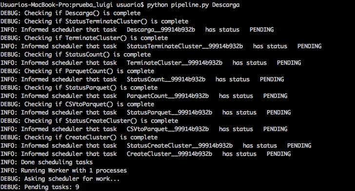

correr

Al correr esto y completarse los tasks nos da este mensaje

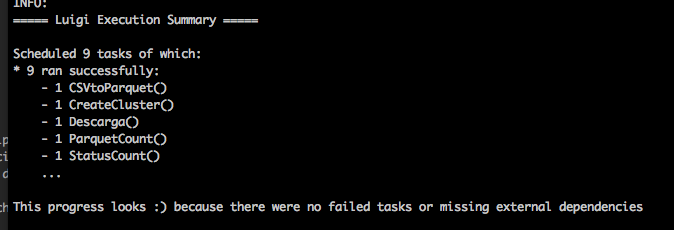

output

El cuál nos indica que todo salió bien.

Del lado de la consola de AWS podemos ver como:

1.- Se crea el cluster:

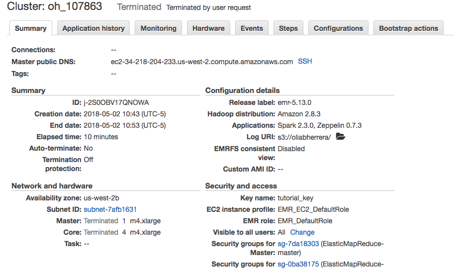

2.- Se hacen steps:

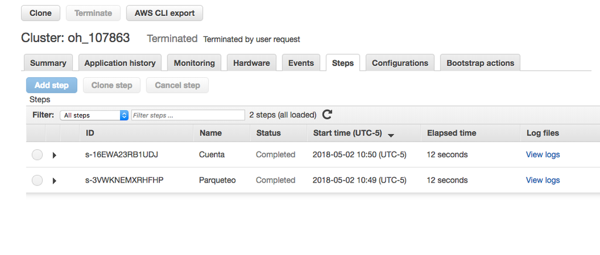

steps

[figure not shown]

resultados

Los resultados que arroja son de este tipo (conteo por producto):

CAJA 510 GR.,20384 FRASCO 200 GR. MEZCLADO CON AZUCAR,4729 UN 32C4000PD. COLOR 32 PLGS. PANTALLA CRISTAL LIQUIDO LED. C/RECUADRO,1064 CJ 631. EXPRIMIDOR,8039

## 0.2 Detalle de los tasks

En total hay 9 Tasks en nuestro pipe.

En orden de ejecución son: - CreateCluster.- Crea el cluster  
- StatusCreateCluster.- Monitorea la creación del cluster  
- CSVtoParquet.- Transforma de Csv a parquet  
- StatusParquet.- Cuida el status del step de CSV a parquet  
- ParquetCount.- Conteo de número de productos  
- StatusCount.- Cuida el status del conteo de número de productos  
- TerminateCluster.- Termina el clúster  
- StatusTerminateCluster.- Cuida el status de terminación de clúster  
- Descarga.- Descarga de archivos a local